# Recovering known states and parameters

Andrew Tredennick

19 July, 2018

## Purpose

The purpose of this document and code is to simulate a stochastic, discrete time SIR model that mimics the dynamics of measles, in particular the measles dynamics observed in some of the regional-level Niger data from 1995-2005. After simulating the model, we use JAGS to fit a state-space model to the simulated case report “data.” This is a test to make sure our model can recover known parameters and states.

## Preliminaries

We need to load a few packages.

```r
library(tidyverse)
library(lubridate)
library(MASS)
library(splines)
library(rjags)
library(coda)
library(cowplot)

theme_set(theme_minimal())  # set ggplot2 theme for all plots
```

## The simulation model

The first step is to simulate a time series from a stochastic SIR model that mimics the behavior observed in our focal time series, measles dynamics at the regional level in Niger. For context, the observed time seris of interest is shown below.

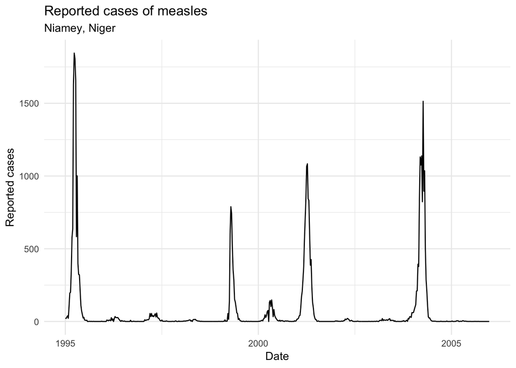

```r
file_name <- "../../niger_measles/niger_regional_1995_2005.csv"
niger_measles_raw <- read_csv(file_name, col_types = cols())

num_regions <- nrow(niger_measles_raw)
num_weeks <- ncol(niger_measles_raw) - 1  # subtract 1 from ncol() because first column are regions
weeks_per_year <- num_weeks/11
weeks <- rep(1:52, times = 11)

# Create a vector of years for all num_weeks
years <- rep(1995:2005, each = weeks_per_year)

# Function for calculating start of week based on week number and year
calculate_start_of_week = function(week, year) {
  date <- ymd(paste(year, 1, 1, sep="-"))
  week(date) = week
  return(date)
}

# Clean up the data frame
measles_data <- niger_measles_raw %>%
  gather(key = week, value = cases, -X1) %>%
  mutate(
    week_num = rep(1:num_weeks, each = num_regions),
    year = rep(years, each  = num_regions),
    week = rep(weeks, each = num_regions),
    date = calculate_start_of_week(week, year)
  ) %>%
  dplyr::rename(region = X1) %>%
  filter(region == "Niamey (City)")

# Plot the time series
ggplot(measles_data, aes(x = date, y = cases)) +
  geom_line() +
  labs(x = "Date", y = "Reported cases") +
  ggtitle("Reported cases of measles", subtitle = "Niamey, Niger")
```

We simulated measles dynamics based on the following stochastic, discrete time SIR model:

$$y_t \sim \text{Negative Binomial}(\rho I_t, \eta) \\
\lambda_t = e^{-\beta_t (I_t + \psi)} \\
\Delta_t \sim \text{Binomial}(\lambda_t, S_t) \\
I_{t+1} = S_t - \Delta_t, \\
S_{t+1} = b_t + \Delta_t,\\
\beta_t = \gamma_t \left[1 + \nu\;\text{sin}\left(\frac{2 \pi t}{26} + \theta \right) \right] , \\
\gamma_t = \gamma_0 + t\;\text{log}(1-r) + \varepsilon_t, \\
\varepsilon_t \sim \text{Normal}(0,\sigma^2).$$

Descriptions of the parameters are in the table below. Seasonality is modeled as a sin wave function that is imposed on a time-varying transmission rate ($\beta_t$).

| Parameter | Definition |
| --- | --- |
| $I_t$ | Number of infected individuals at time *t* (latent). |
| $S_t$ | Number of susceptible individuals at time *t* (latent). |
| $y_t$ | Number of reported cases at time *t* (observed). |
| $\rho$ | Reporting fraction. |
| $b_t$ | Number of births at time *t*. |
| $\lambda_t$ | Probability of escaping infection at time *t*. |
| $\Delta_t$ | Number of susceptibles that escape infection at *t*. |
| $\beta_t$ | Seasonally forced transmission rate at time *t*. |
| $\gamma_t$ | Transmission rate at time *t*. |
| $\gamma_0$ | Initial T transmission rate at time 0. |
| $\nu$ | Amplitude of sin wave. |
| $\theta$ | Phase of sin wave. |
| $\varepsilon_t$ | Noise on transmission rate at time *t*. |
| $\sigma^2$ | Variance of noise term for transmission rate. |

### Simulator function

Here we present the function we used to simulate dynamics from the model specified above.

```r
simulate_measles <- function(S0, I0, b, psi, rho, gamma0, r, nu, theta, sigma, dispersion, years){
  # Function to simulate disease dynamics similar to measles
  #
  # Args:
  #  S0: initial susceptible pool
  #  I0: initial infected pool
  #  b: biweekly number of births
  #  psi: per individual immigration of infection rate
  #  rho: reporting fraction (between 0 and 1)
  #  gamma0: inital rate of transmission on log scale
  #  r: growth/decay rate of tranmission rate through time
  #  nu: amplitude of sin wave for seasonality
  #  theta: phase of sin wave
  #  sigma: standard deviation of environmental noise on transmission rate
  #  dispersion: dispersion parameter for the negative binomial observation process
  #  years: number of years to simulate
  #
  # Returns:
  #  A tibble (dataframe) with the following columns:
  #   time: timestep of the simulation
  #   susceptible: number of persons in the susceptible class
  #   infected: number of persons in the infected class
  #   case_reports: number of reported infections
  #   beta: time-varying transmission rate
  #   beta_season: time-varying transmission rate with seasonality

  # Define state and parameter vectors
  timesteps <- years*26
  I <- numeric(timesteps)
  I[1] <- I0
  S <- numeric(timesteps)
  S[1] <- S0
  beta <- numeric(timesteps)
  beta_season <- numeric(timesteps)
  vareps <- rnorm(timesteps, 0, sigma)  # generate errors outside of loop

  # Define seasonality
  season <- function(nu, phi, t){
    nu * sin( (2*pi*t)/26 + phi )
  }

  # Iterate the process
  for(t in 1:(timesteps-1)){
    beta[t] <- gamma0 + t * log(1-r) + vareps[t]
    beta_season[t] <- exp(beta[t]) * (1 + season(nu, theta, t))
    lambda <- exp(-beta_season[t] * (I[t] + psi))
    Delta <- rbinom(n = 1, size = S[t], prob = lambda)  # stochastic transmission
    I[t+1] <-  S[t] - Delta
    S[t+1] <-  b[t] + Delta
  }

  reported_cases <- rnegbin(n = timesteps, mu = rho*I, theta = dispersion)

  out_tbl <- tibble(
    year = rep(1:years, each = 26),
    time = 1:timesteps,
    susceptible = S,
    infected = I,
    case_reports = reported_cases,
    beta = beta,
    beta_season = beta_season
  )
}
```

### Simulation results

Here we present the results from a single simulation.

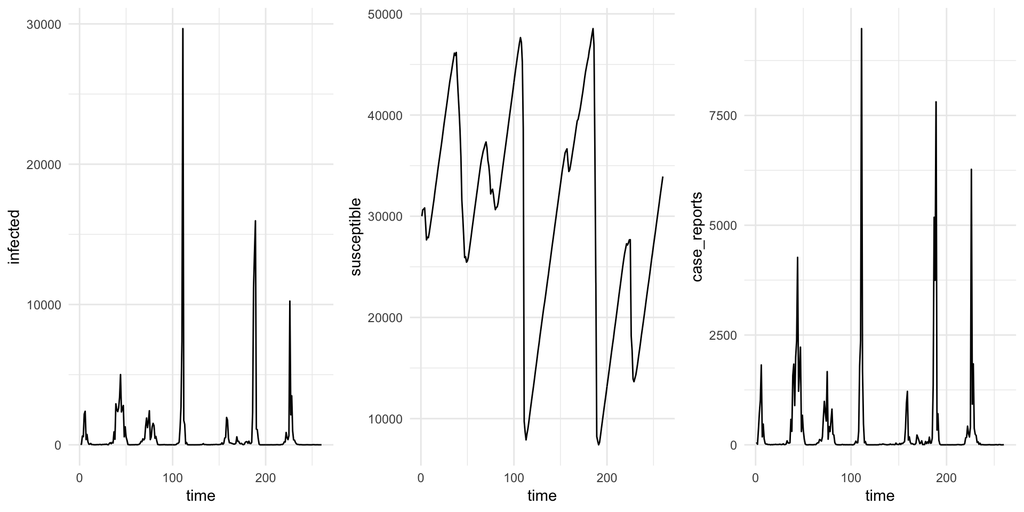

```r
# Set parameter values and initial conditions
years <- 10
S0 <- 30000
I0 <- 50
b <- rpois(20*26, 700)
psi <- 1.5
rho <- 0.5
gamma0 <- log(0.00003)
r <- 0.0001
nu <- 0.12
theta <- 13
sigma <- 1
dispersion <- 5

# Call the function
sim_out <- simulate_measles(S0, I0, b, psi, rho, gamma0, r, nu, theta, sigma, dispersion, years)

# Plot the results
infected <- ggplot(sim_out, aes(x = time, y = infected)) +
  geom_line()

susceptible <- ggplot(sim_out, aes(x = time, y = susceptible)) +
  geom_line()

reports <- ggplot(sim_out, aes(x = time, y = case_reports)) +
  geom_line()

cowplot::plot_grid(infected, susceptible, reports, nrow = 1)
```